# ACFexample

```python
import lightkurve as lk
import numpy as np
import matplotlib.pyplot as plt
from pylab import *
import pandas as pd
import astropy.units as u
import math
import warnings
from IPython.display import Image
warnings.simplefilter(action='ignore')

plt.rcParams['figure.dpi'] = 100
```

Here's a sample lightcurve for some data:

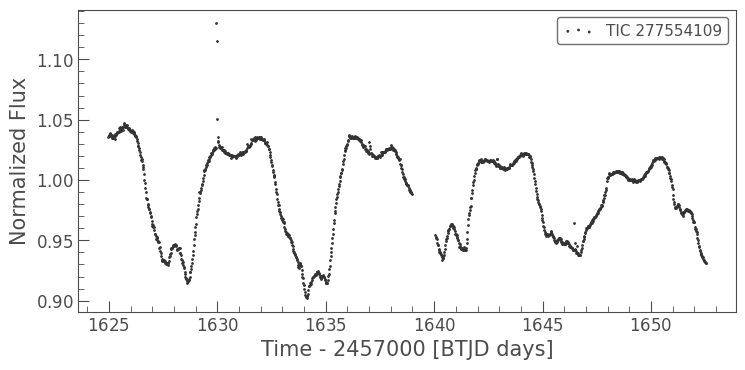

```python
lc=lk.search_lightcurve("TIC 277554109",author='qlp',sector=12).download()
lc.scatter()
```

There can't be any gaps in the data for the autocorrelation function to work, so I've been using pandas dataframes to order and interpolate the missing/nan values. This is just how I have been filling those in, you may have a different method for this or already have complete data

```python
df=pd.DataFrame()
df['time']=lc['time'].value
df['flux']=np.array(lc['flux'].value).byteswap().newbyteorder()
df
```

|  | time | flux |
| --- | --- | --- |
| 0 | 1624.971525 | 1.035775 |
| 1 | 1624.992358 | 1.036420 |
| 2 | 1625.013192 | 1.037324 |
| 3 | 1625.034025 | 1.038673 |
| 4 | 1625.054858 | 1.037019 |
| ... | ... | ... |
| 1277 | 1652.783735 | NaN |
| 1278 | 1652.804568 | NaN |
| 1279 | 1652.825401 | NaN |
| 1280 | 1652.846234 | NaN |
| 1281 | 1652.867067 | NaN |

1282 rows × 2 columns

```python
times=np.arange(1638.85,1640.15,0.05)
for i in times:
    df = df.append({'time': i}, ignore_index=True)
df=df.sort_values(by=['time'])
df=df.interpolate(method='linear')
df=df.sort_values(by=['time'])
df=df.reset_index()
```

The autocorrelation function:

```python
def autocorr(x):
    result = np.correlate(x-np.mean(x), x-np.mean(x), mode='full')
    return result[int(np.floor(result.size/2)):]
```

```python
acf=autocorr(df['flux'].values)
acf
```

```
array([ 1.8628185 ,  1.8502274 ,  1.8360071 , ..., -0.0082981 ,
       -0.00548607, -0.00272492], dtype=float32)
```

The ACF plot is lag (how far shifted) vs ACF (correlation between lighturve and itself shifted by time) and so this is how I convert the x axis from light curve points to days which may differ for you depending on what your expected period is and your data: (my conversion here is based on most of my data having 30 minute sampling)

```python
days=np.arange(len(acf))*(30/60/24)
# basically just np.arange(len(acf)) times your conversion
# One suggestion was to use *(np.median(np.diff(df.time))) rather than *(30/60/24) which only works based on this current data
# I tried it and it gives me the same thing
```

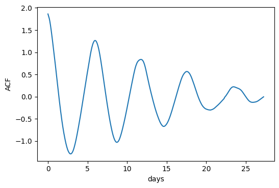

```python
plt.plot(days,acf)
plt.xlabel('days');
plt.ylabel('ACF');
```

So the general idea is that we want to find the maximum in the ACF (after the first dip) and identify the location on the x-axis. And while the actual value of the ACF is less important than the position of the peak, the ACF value can indicate whether the periodicity is strong (more periodic should have higher ACF values)

So this is point where my method may not be 100% correct, but I've been using scipy's signal tools to identify the peaks and it seems to have worked well enough so far. I'm still working on other ways to potentially identify local maxima so this may just be a starting point if you want to use a different method. Here's the functions I use though, and the 'gfpeaks' function is for the label on the plot so you can clearly see the values of the points.

```python
from scipy.signal import find_peaks
from scipy.signal import peak_prominences
```

```python
# You'll also want to change the conversion here
def gfpeaks(p):
    l=[]
    for i in range(len(p)):
        l.append(r"acf: %5.4f" %acf[p[i]] +"     %5.4f" %(np.arange(len(acf))*(30/60/24))[p[i]]+' days')
    butFirst = l[0:]
    S = "\n".join(butFirst)
    return S
```

The trickiest part of the find_peaks function is choosing good height and distance values to use, which will vary based on your data. I have been using the maximum of the acf divided by some number (because we want to ignore that first spike) which usually will give me either one or a few peaks but you may need to play with those until it gives you a peak. Before that I was basically just doing guess and check until it gave me something becuase the distance isn't based on the actual x values.

```python
peaks,prop=find_peaks(acf,height=max(acf)/2,distance=15)
peaks
```

```
array([286])
```

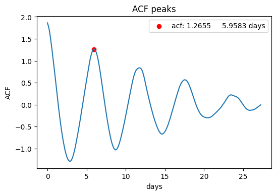

```python
# ACF plot again, now with the peaks marked and labeled with gfpeaks
plt.plot(days,acf)
plt.scatter(days[peaks],acf[peaks],color='r',label=gfpeaks(peaks))
plt.title('ACF peaks');
plt.xlabel('days');
plt.ylabel('ACF');
plt.legend();
```

Now for phase folding I wrote this so that if there's multiple peaks from the find_peaks function it can add subplots for comparison purposes. This may also need to be modified depending on your number of peaks or how you want to display the phase folded curve.

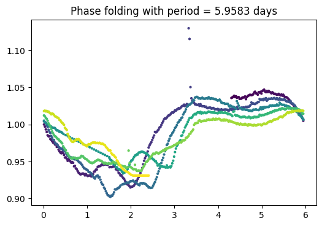

```python
if peaks.shape[0]>1:
    num=peaks.shape[0]
    fig=plt.figure(figsize=[14,8])
    fig.suptitle('Phase folding',y=0.95)
    for i,v in enumerate(range(len(peaks))):
        fig.add_subplot(num,2,i+1)
        plt.scatter(df.time%days[peaks[v]],df.flux,c=df.time,s=num)
        plt.subplots_adjust(hspace=0.5,wspace=0.3)
        plt.title( r" %5.4f" %days[peaks][v]+' days')
else:
    plt.scatter(df.time%days[peaks[0]],df.flux,c=df.time,s=4)
    plt.title( r"Phase folding with period = %5.4f" %days[peaks[0]]+' days')
```

So here's an example if you want to compare multiple peaks:

```python
peaks,prop=find_peaks(acf,height=max(acf)/3,distance=15)
# notice different height^ now gives two peaks:
peaks
```

```
array([286, 564])
```

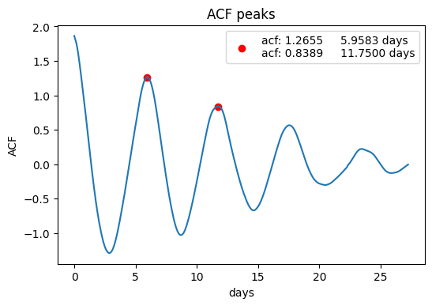

```python
plt.plot(days,acf)
plt.scatter(days[peaks],acf[peaks],color='r',label=gfpeaks(peaks))
plt.title('ACF peaks');
plt.xlabel('days');
plt.ylabel('ACF');
plt.legend();
```

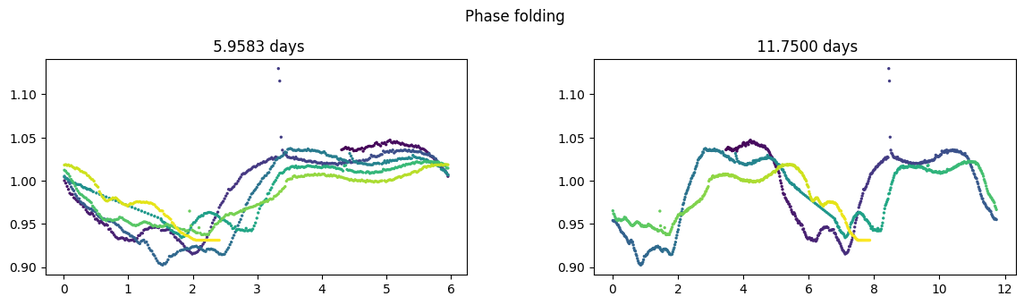

```python
if peaks.shape[0]>1:
    num=peaks.shape[0]
    fig=plt.figure(figsize=[14,8])
    fig.suptitle('Phase folding',y=0.95)
    for i,v in enumerate(range(len(peaks))):
        fig.add_subplot(num,2,i+1)
        plt.scatter(df.time%days[peaks[v]],df.flux,c=df.time,s=num)
        plt.subplots_adjust(hspace=0.5,wspace=0.3)
        plt.title( r" %5.4f" %days[peaks][v]+' days')
else:
    plt.scatter(df.time%days[peaks[0]],df.flux,c=df.time,s=4)
    plt.title( r"Phase folding with period = %5.4f" %days[peaks[0]]+' days')
```

Then if you want to fit one of these or use the phase fold time in any way you'd just want to define a folded time with that df.time%days[peaks[0]] bit and the index of whatever peak you want and sort your flux by that